# Lab6

Author

Shuchen Wu

## Load data

```r
# install.packages("tidytext")
library(dplyr)
library(ggplot2)
library(tidytext)
library(readr)

mtsamples <- read_csv(
  "https://raw.githubusercontent.com/dmcable/BIOSTAT620W26/main/data/mtsamples/mtsamples.csv"
)
# quick check
glimpse(mtsamples)
```

```
Rows: 4,999
Columns: 6
$ ...1              <dbl> 0, 1, 2, 3, 4, 5, 6, 7, 8, 9, 10, 11, 12, 13, 14, 15…
$ description       <chr> "A 23-year-old white female presents with complaint …
$ medical_specialty <chr> "Allergy / Immunology", "Bariatrics", "Bariatrics", …
$ sample_name       <chr> "Allergic Rhinitis", "Laparoscopic Gastric Bypass Co…
$ transcription     <chr> "SUBJECTIVE:,  This 23-year-old white female present…
$ keywords          <chr> "allergy / immunology, allergic rhinitis, allergies,…
```

```r
head(mtsamples)
```

```
# A tibble: 6 × 6
   ...1 description         medical_specialty sample_name transcription keywords
  <dbl> <chr>               <chr>             <chr>       <chr>         <chr>
1     0 A 23-year-old whit… Allergy / Immuno… Allergic R… "SUBJECTIVE:… allergy…
2     1 Consult for laparo… Bariatrics        Laparoscop… "PAST MEDICA… bariatr…
3     2 Consult for laparo… Bariatrics        Laparoscop… "HISTORY OF … bariatr…
4     3 2-D M-Mode. Dopple… Cardiovascular /… 2-D Echoca… "2-D M-MODE:… cardiov…
5     4 2-D Echocardiogram  Cardiovascular /… 2-D Echoca… "1.  The lef… cardiov…
6     5 Morbid obesity.  L… Bariatrics        Laparoscop… "PREOPERATIV… bariatr…
```

## Question 1

```r
spec_counts <- mtsamples %>%
  count(medical_specialty, sort = TRUE)

spec_counts
```

```
# A tibble: 40 × 2
   medical_specialty                 n
   <chr>                         <int>
 1 Surgery                        1103
 2 Consult - History and Phy.      516
 3 Cardiovascular / Pulmonary      372
 4 Orthopedic                      355
 5 Radiology                       273
 6 General Medicine                259
 7 Gastroenterology                230
 8 Neurology                       223
 9 SOAP / Chart / Progress Notes   166
10 Obstetrics / Gynecology         160
# ℹ 30 more rows
```

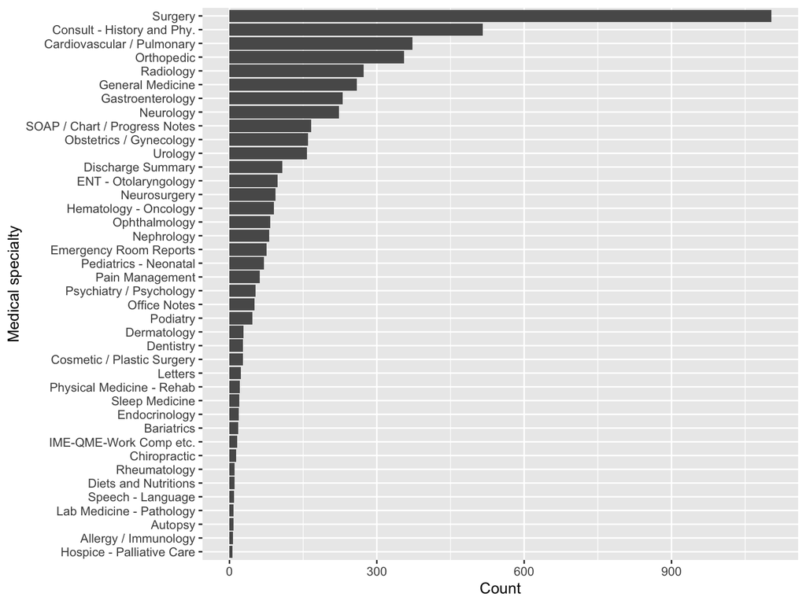

```r
ggplot(spec_counts, aes(x = reorder(medical_specialty, n), y = n)) +
  geom_col() +
  coord_flip() +
  labs(x = "Medical specialty", y = "Count")
```

There are a total of 40 medical_specialty categories.

These categories are clearly related and conceptually overlap. One group consists of true “specialties/departments” (e.g., Surgery, Orthopedics, Radiology, Neurology, Urology, etc.). Another group is more like “document/record types or scenarios,” not entirely specialists (e.g., SOAP/Chart/Progress Notes, Discharge Summary, Office Notes, Letters, Emergency Room Reports, etc.).

Therefore, they are not completely mutually exclusive or at the same level of classification: The same medical record might belong to a specific specialty (e.g., Surgery) and also to a certain record type (e.g., Discharge Summary or SOAP note). The dataset simply assigns a label to each record, so what you see is a “single classification at the label level,” but semantic overlap exists.

The distribution is completely uneven (highly skewed), exhibiting a typical “long-tail distribution”:

The largest class is Surgery = 1103, accounting for approximately 1103/4999 = 22%.

The top 10 classes combined account for 3657/4999 = 73%, indicating that most samples are concentrated in a few categories.

The tail categories have extremely few samples (e.g., Hospice - Palliative Care = 6, Allergy/Immunology = 7, Autopsy = 8, etc.), and these categories may be very unstable in subsequent analyses (due to insufficient sample size).

## Question 2

```r
word_counts <- mtsamples %>%
  select(transcription) %>%
  unnest_tokens(word, transcription) %>%
  count(word, sort = TRUE)

top20 <- word_counts %>% slice_head(n = 20)
top20
```

```
# A tibble: 20 × 2
   word         n
   <chr>    <int>
 1 the     149888
 2 and      82779
 3 was      71765
 4 of       59205
 5 to       50632
 6 a        42810
 7 with     35815
 8 in       32807
 9 is       26378
10 patient  22065
11 no       17874
12 she      17593
13 for      17049
14 he       15542
15 were     15535
16 on       14694
17 this     13949
18 at       13492
19 then     12430
20 right    11587
```

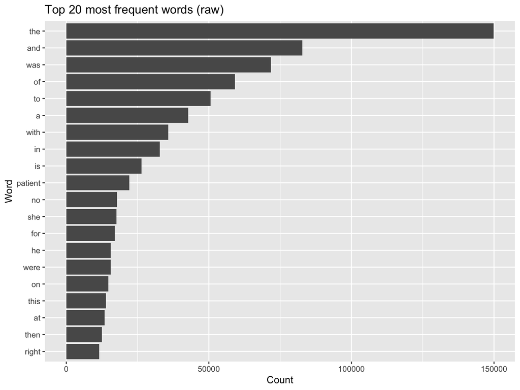

```r
top20 %>%
  ggplot(aes(x = reorder(word, n), y = n)) +
  geom_col() +
  coord_flip() +
  labs(x = "Word", y = "Count", title = "Top 20 most frequent words (raw)")
```

From the raw token counts, the most frequent words are common English function words such as “the”, “and”, “was”, “of”, “to”, “a”, “with”, “in”, “is”. This is expected because the transcription field contains long narrative sentences, so high-frequency stop words dominate the counts.

This result makes sense, but it provides limited domain insight: these words reflect grammar rather than medical content. The first medically meaningful token that appears in the top 20 is “patient”, which is consistent with clinical notes frequently referring to the patient throughout the report.

Overall, the main takeaway is that a “raw” frequency plot is mostly measuring stop words; to get more informative insights about medical themes, we would typically remove stop words (and possibly punctuation/numbers) before examining frequent terms.

## Question 3

```r
library(stringr)

data("stop_words")

word_counts_clean <- mtsamples %>%
  select(transcription) %>%
  unnest_tokens(word, transcription) %>%
  anti_join(stop_words, by = "word") %>%
  filter(!str_detect(word, "^[0-9]+$")) %>%
  count(word, sort = TRUE)

top20_clean <- word_counts_clean %>% slice_head(n = 20)
top20_clean
```

```
# A tibble: 20 × 2
   word           n
   <chr>      <int>
 1 patient    22065
 2 left       11258
 3 history     9509
 4 normal      7526
 5 procedure   7463
 6 pain        5976
 7 noted       4348
 8 time        4287
 9 mg          4087
10 blood       3956
11 performed   3953
12 skin        3798
13 anesthesia  3707
14 incision    3601
15 removed     3532
16 diagnosis   3212
17 artery      3027
18 anterior    2932
19 disease     2682
20 past        2674
```

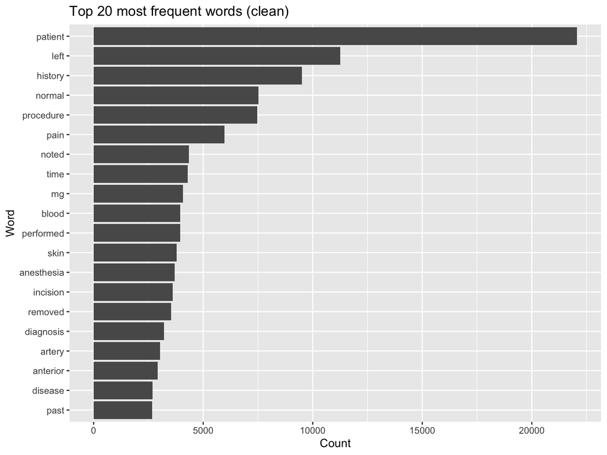

```r
top20_clean %>%
  ggplot(aes(x = reorder(word, n), y = n)) +
  geom_col() +
  coord_flip() +
  labs(x = "Word", y = "Count", title = "Top 20 most frequent words (clean)")
```

After removing stop words (and numeric tokens), the most frequent words shift from common function words (e.g., the, and, of) to content-bearing clinical terms. The top words include patient, history, diagnosis, procedure, pain, and blood, which are all central concepts in medical reports. We also see anatomy/location terms such as left, anterior, artery, and clinical/action words such as performed, incision, removed, and anesthesia, consistent with operative or procedural documentation.

This result gives a much better idea of what the text is about: the corpus is largely describing patients, their clinical history, diagnoses, and medical procedures/treatments. Compared to the raw top-20 list, the cleaned list is more interpretable and highlights the medical nature of the dataset.

One remaining artifact is “mg”, which appears frequently because medication dosages are commonly recorded. If desired, we could also filter common units (e.g., mg, ml, cm) to focus even more on clinical concepts.

## Question 4

```r
library(tidyr)

data("stop_words")

bigram_counts <- mtsamples %>%
  select(transcription) %>%
  unnest_tokens(bigram, transcription, token = "ngrams", n = 2) %>%
  separate(bigram, into = c("w1", "w2"), sep = " ") %>%
  filter(!w1 %in% stop_words$word,
         !w2 %in% stop_words$word) %>%
  filter(!str_detect(w1, "^[0-9]+$"),
         !str_detect(w2, "^[0-9]+$")) %>%
  unite(bigram, w1, w2, sep = " ") %>%
  count(bigram, sort = TRUE)

top20_bigram <- bigram_counts %>% slice_head(n = 20)
top20_bigram
```

```
# A tibble: 20 × 2
   bigram                      n
   <chr>                   <int>
 1 blood pressure           1265
 2 medical history          1223
 3 preoperative diagnosis   1176
 4 physical examination     1156
 5 vital signs              1121
 6 past medical             1113
 7 postoperative diagnosis  1092
 8 coronary artery          1032
 9 patient tolerated         994
10 blood loss                965
11 family history            941
12 social history            865
13 stable condition          835
14 supine position           786
15 status post               783
16 estimated blood           754
17 sterile fashion           721
18 mg p.o                    718
19 chest pain                707
20 informed consent          685
```

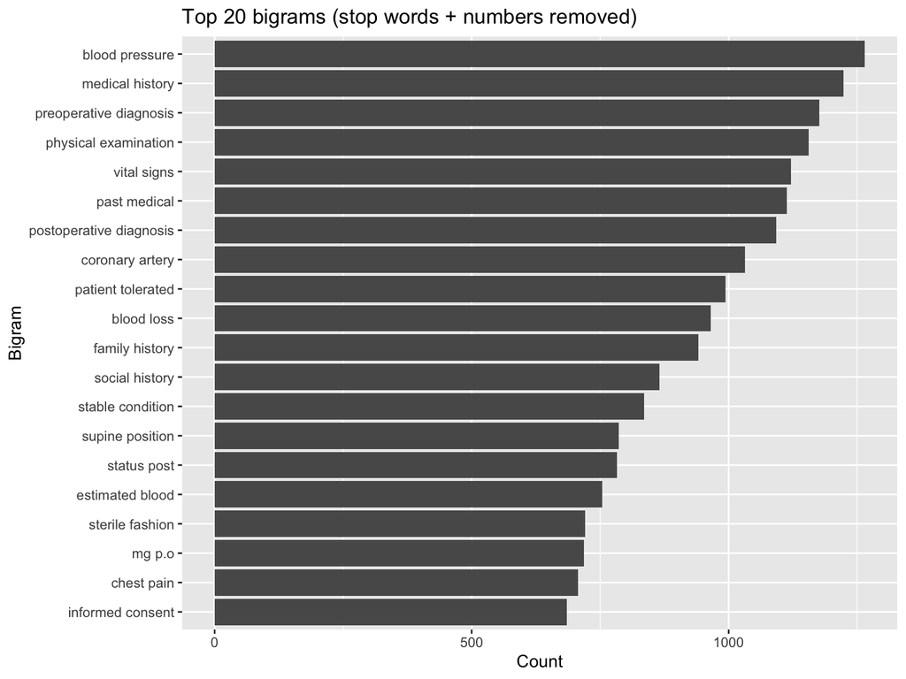

```r
top20_bigram %>%
  ggplot(aes(x = reorder(bigram, n), y = n)) +
  geom_col() +
  coord_flip() +
  labs(x = "Bigram", y = "Count", title = "Top 20 bigrams (stop words + numbers removed)")
```

```r
trigram_counts <- mtsamples %>%
  select(transcription) %>%
  unnest_tokens(trigram, transcription, token = "ngrams", n = 3) %>%
  separate(trigram, into = c("w1", "w2", "w3"), sep = " ") %>%
  filter(!w1 %in% stop_words$word,
         !w2 %in% stop_words$word,
         !w3 %in% stop_words$word) %>%
  filter(!str_detect(w1, "^[0-9]+$"),
         !str_detect(w2, "^[0-9]+$"),
         !str_detect(w3, "^[0-9]+$")) %>%
  unite(trigram, w1, w2, w3, sep = " ") %>%
  count(trigram, sort = TRUE)

top20_trigram <- trigram_counts %>% slice_head(n = 20)
top20_trigram
```

```
# A tibble: 20 × 2
   trigram                        n
   <chr>                      <int>
 1 past medical history        1063
 2 estimated blood loss         754
 3 coronary artery disease      419
 4 past surgical history        419
 5 examination vital signs      404
 6 physical examination vital   404
 7 usual sterile fashion        376
 8 mg p.o daily                 273
 9 left anterior descending     269
10 left lower extremity         192
11 heart regular rate           189
12 blood loss minimal           176
13 abdomen soft nontender       172
14 vital signs blood            170
15 congestive heart failure     169
16 signs blood pressure         167
17 normal sinus rhythm          162
18 cranial nerves ii            159
19 transverse carpal ligament   159
20 vital signs temperature      156
```

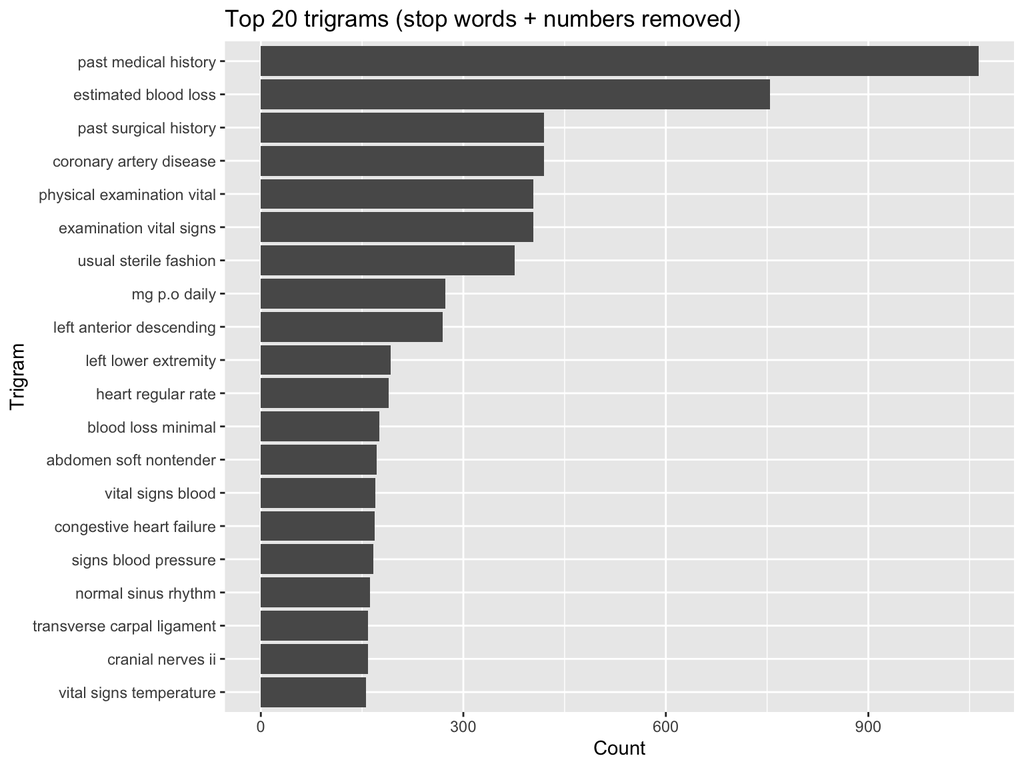

```r
top20_trigram %>%
  ggplot(aes(x = reorder(trigram, n), y = n)) +
  geom_col() +
  coord_flip() +
  labs(x = "Trigram", y = "Count", title = "Top 20 trigrams (stop words + numbers removed)")
```

Bigrams: Compared with unigrams, the most frequent bigrams are clearly more meaningful clinical phrases rather than isolated words. Many top bigrams reflect standard sections or repeated content in medical notes, such as “medical history,” “physical examination,” “vital signs,” “family history,” “social history,” and common clinical measures like “blood pressure.” We also see procedure-related phrases such as “preoperative diagnosis,” “postoperative diagnosis,” “blood loss,” “informed consent,” and “sterile fashion,” which suggests that a substantial portion of the transcripts are operative/procedural reports.

Trigrams: When moving to trigrams, the phrases become even more specific and read like common note templates. Examples include “past medical history,” “past surgical history,” “estimated blood loss,” “coronary artery disease,” “usual sterile fashion,” “blood loss minimal,” and exam/vitals phrases like “examination vital signs” / “vital signs temperature.” These provide clearer context about how the notes are written (structured, templated clinical documentation) and what topics appear frequently (history, vitals, cardiovascular disease, surgery/procedures).

How the result changes from bigrams to trigrams:  
The main change is that trigrams are more informative but less frequent/sparser: exact 3-word sequences repeat less often than 2-word sequences, so counts drop and the list becomes more “template-like.” In other words, bigrams capture common collocations (e.g., blood pressure), while trigrams capture more complete clinical phrases and documentation patterns (e.g., past medical history, estimated blood loss).

## Question 5

```r
target <- "blood"

bigrams_all <- mtsamples %>%
  select(transcription) %>%
  unnest_tokens(bigram, transcription, token = "ngrams", n = 2) %>%
  separate(bigram, into = c("w1", "w2"), sep = " ")

before_tbl <- bigrams_all %>%
  filter(w2 == target) %>%
  count(word_before = w1, sort = TRUE)

after_tbl <- bigrams_all %>%
  filter(w1 == target) %>%
  count(word_after = w2, sort = TRUE)

before_tbl %>% slice_head(n = 15)
```

```
# A tibble: 15 × 2
   word_before     n
   <chr>       <int>
 1 estimated     754
 2 white         180
 3 signs         170
 4 and           154
 5 of            149
 6 red           123
 7 her           116
 8 his            99
 9 the            96
10 no             72
11 a              68
12 high           55
13 pounds         48
14 for            45
15 with           38
```

```r
after_tbl  %>% slice_head(n = 15)
```

```
# A tibble: 15 × 2
   word_after      n
   <chr>       <int>
 1 pressure     1265
 2 loss          965
 3 cell          130
 4 in            114
 5 cells         112
 6 sugar          91
 7 and            84
 8 sugars         79
 9 was            65
10 cultures       53
11 flow           45
12 transfusion    42
13 work           39
14 glucose        37
15 or             33
```

```r
data("stop_words")

bigrams_all_clean <- bigrams_all %>%
  filter(!w1 %in% stop_words$word,
         !w2 %in% stop_words$word) %>%
  filter(!str_detect(w1, "^[0-9]+$"),
         !str_detect(w2, "^[0-9]+$"))

before_tbl <- bigrams_all_clean %>%
  filter(w2 == target) %>%
  count(word_before = w1, sort = TRUE)

after_tbl <- bigrams_all_clean %>%
  filter(w1 == target) %>%
  count(word_after = w2, sort = TRUE)

before_tbl %>% slice_head(n = 15)
```

```
# A tibble: 15 × 2
   word_before     n
   <chr>       <int>
 1 estimated     754
 2 white         180
 3 signs         170
 4 red           123
 5 pounds         48
 6 cold           29
 7 cord           28
 8 fasting        28
 9 elevated       27
10 patient's      26
11 low            24
12 oral           24
13 examination    23
14 arterial       21
15 venous         19
```

```r
after_tbl  %>% slice_head(n = 15)
```

```
# A tibble: 15 × 2
   word_after      n
   <chr>       <int>
 1 pressure     1265
 2 loss          965
 3 cell          130
 4 cells         112
 5 sugar          91
 6 sugars         79
 7 cultures       53
 8 flow           45
 9 transfusion    42
10 glucose        37
11 return         33
12 vessels        33
13 pressures      31
14 culture        30
15 clots          27
```

## Question 6

```r
data("stop_words")

top5_by_spec <- mtsamples %>%
  select(medical_specialty, transcription) %>%
  unnest_tokens(word, transcription) %>%
  anti_join(stop_words, by = "word") %>%
  filter(!str_detect(word, "^[0-9]+$")) %>%
  count(medical_specialty, word, sort = TRUE) %>%
  group_by(medical_specialty) %>%
  top_n(5, n) %>%
  arrange(medical_specialty, desc(n))

top5_by_spec
```

```
# A tibble: 210 × 3
# Groups:   medical_specialty [40]
   medical_specialty    word          n
   <chr>                <chr>     <int>
 1 Allergy / Immunology history      38
 2 Allergy / Immunology noted        23
 3 Allergy / Immunology patient      22
 4 Allergy / Immunology allergies    21
 5 Allergy / Immunology nasal        13
 6 Allergy / Immunology past         13
 7 Autopsy              left         83
 8 Autopsy              inch         59
 9 Autopsy              neck         55
10 Autopsy              anterior     47
# ℹ 200 more rows
```

```r
top5_summary <- top5_by_spec %>%
  group_by(medical_specialty) %>%
  summarise(top5_words = paste(word, collapse = ", "), .groups = "drop")

top5_summary
```

```
# A tibble: 40 × 2
   medical_specialty          top5_words
   <chr>                      <chr>
 1 Allergy / Immunology       history, noted, patient, allergies, nasal, past
 2 Autopsy                    left, inch, neck, anterior, body
 3 Bariatrics                 patient, history, weight, surgery, gastric
 4 Cardiovascular / Pulmonary left, patient, artery, coronary, history
 5 Chiropractic               pain, patient, dr, history, left
 6 Consult - History and Phy. patient, history, normal, pain, mg
 7 Cosmetic / Plastic Surgery patient, procedure, breast, skin, incision
 8 Dentistry                  patient, tooth, teeth, left, procedure
 9 Dermatology                patient, skin, cm, left, procedure
10 Diets and Nutritions       patient, weight, carbohydrate, day, food, plan
# ℹ 30 more rows
```

## Question 7

```r
surg_patterns <- c(
  "preoperative diagnosis",
  "postoperative diagnosis",
  "estimated blood loss",
  "usual sterile fashion",
  "informed consent"
)

flag_tbl <- mtsamples %>%
  mutate(
    txt = str_to_lower(transcription),
    has_surg_phrase = str_detect(txt, paste(surg_patterns, collapse = "|"))
  ) %>%
  group_by(medical_specialty) %>%
  summarise(
    n_docs = n(),
    prop_surg_phrase = mean(has_surg_phrase),
    .groups = "drop"
  ) %>%
  arrange(desc(prop_surg_phrase), desc(n_docs))

flag_tbl %>% slice_head(n = 15)
```

```
# A tibble: 15 × 3
   medical_specialty          n_docs prop_surg_phrase
   <chr>                       <int>            <dbl>
 1 Neurosurgery                   94           0.755
 2 Cosmetic / Plastic Surgery     27           0.630
 3 Ophthalmology                  83           0.602
 4 Dentistry                      27           0.593
 5 Orthopedic                    355           0.521
 6 Podiatry                       47           0.362
 7 Nephrology                     81           0.358
 8 Dermatology                    29           0.345
 9 Endocrinology                  19           0.316
10 Hematology - Oncology          90           0.311
11 Bariatrics                     18           0.222
12 Pediatrics - Neonatal          70           0.129
13 Neurology                     223           0.108
14 Radiology                     273           0.0733
15 Discharge Summary             108           0.0370
```

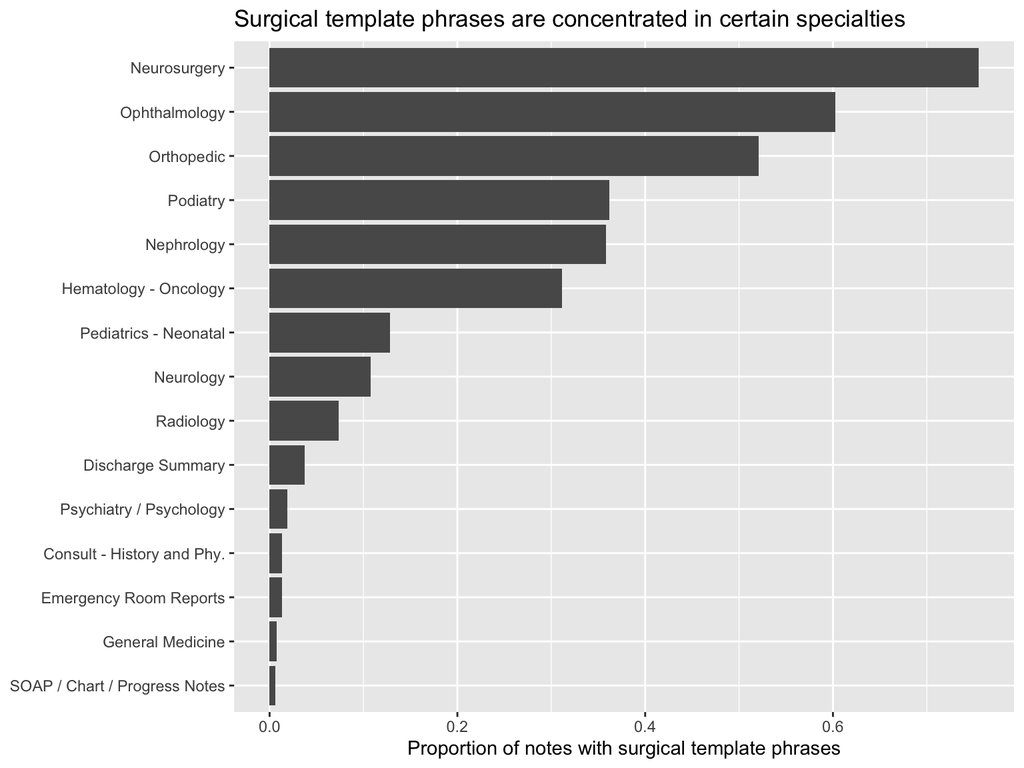

```r
flag_tbl %>%
  filter(n_docs >= 30) %>%
  slice_head(n = 15) %>%
  ggplot(aes(x = reorder(medical_specialty, prop_surg_phrase),
             y = prop_surg_phrase)) +
  geom_col() +
  coord_flip() +
  labs(x = NULL, y = "Proportion of notes with surgical template phrases",
       title = "Surgical template phrases are concentrated in certain specialties")
```

I investigated whether common surgical/operative template phrases (e.g., preoperative diagnosis, postoperative diagnosis, estimated blood loss, usual sterile fashion, informed consent) appear more frequently in some specialties than others. For each medical_specialty, I computed the proportion of notes whose transcription contains at least one of these phrases.

The results show a strong concentration in procedure-heavy specialties. For example, Neurosurgery has the highest proportion (~0.76, 94 notes), followed by Ophthalmology (~0.60, 83 notes) and Orthopedic (~0.52, 355 notes). In contrast, several non-procedural or general note categories (e.g., General Medicine, Emergency Room Reports, SOAP / Chart / Progress Notes) have proportions close to 0, indicating these templated operative phrases are rarely used there.

Overall, this suggests that a substantial subset of the dataset consists of standardized operative reports with repeated clinical documentation templates, and that these templates are much more prevalent in surgical/procedural specialties. This aligns with earlier n-gram results (Q4–Q5), where phrases like “estimated blood loss” and “pre/postoperative diagnosis” appeared among the most frequent bigrams/trigrams.